# COMPSCIX 415.2 Homework 6 SOLUTION

Robert Clements

DUE DATE: Mar 13, 2018 @ 6:15PM

### Exercise 1

Load the `Whickham` dataset (`data(Whickham)`). You will need to load the `mosaicData` package first, but I also included the data as an rds file on Canvas if you would rather download it there and load it with `readRDS()`.

Look at the help file on this dataset to learn a bit about it.

1. What variables are in this data set?

```r
library(mosaicData)
library(tidyverse)
```

The variables in the dataset are outcome, smoker, age.

2. How many observations are there and what does each represent?

There are 1314 rows. Each observation is a woman, her smoking status at the baseline, survival status after 20 years and age at the time of the first survey.

3. Create a table (use the R code below as a guide) and a visualization of the relationship between smoking status and outcome, ignoring age. What do you see? Does it make sense?

```r
library(mosaicData)
library(tidyverse)
Whickham %>% count(smoker, outcome)
```

| smoker | outcome | n |
| --- | --- | --- |
| No | Alive | 502 |
| No | Dead | 230 |
| Yes | Alive | 443 |
| Yes | Dead | 139 |

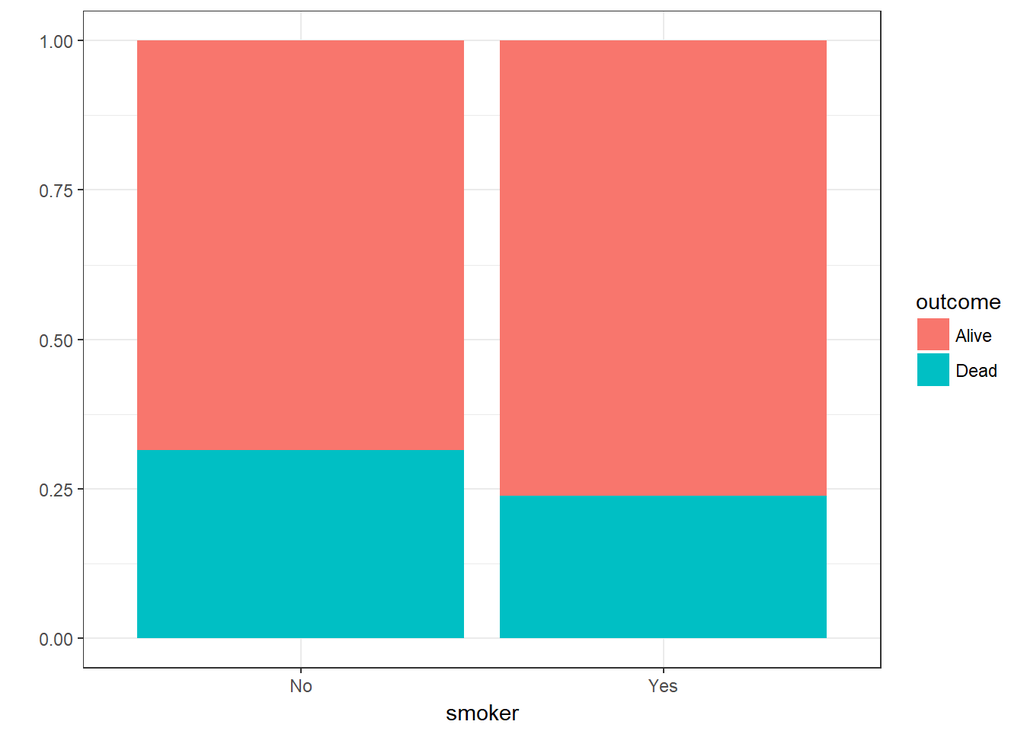

```r
Whickham %>% ggplot(aes(x = smoker, fill = outcome)) +
  geom_bar(position = 'fill') +
  labs(y = '') +
  theme_bw()
```

The plot and table seem to suggest that non-smokers have a higher mortality rate than smokers, which wouldn’t make sense given all we know about the effects of smoking.

4. Recode the `age` variable into an ordered factor with three categories: age <= 44, age > 44 & age <= 64, and age > 64. Now, recreate visualization from above, but facet on your new age factor. What do you see? Does it make sense?

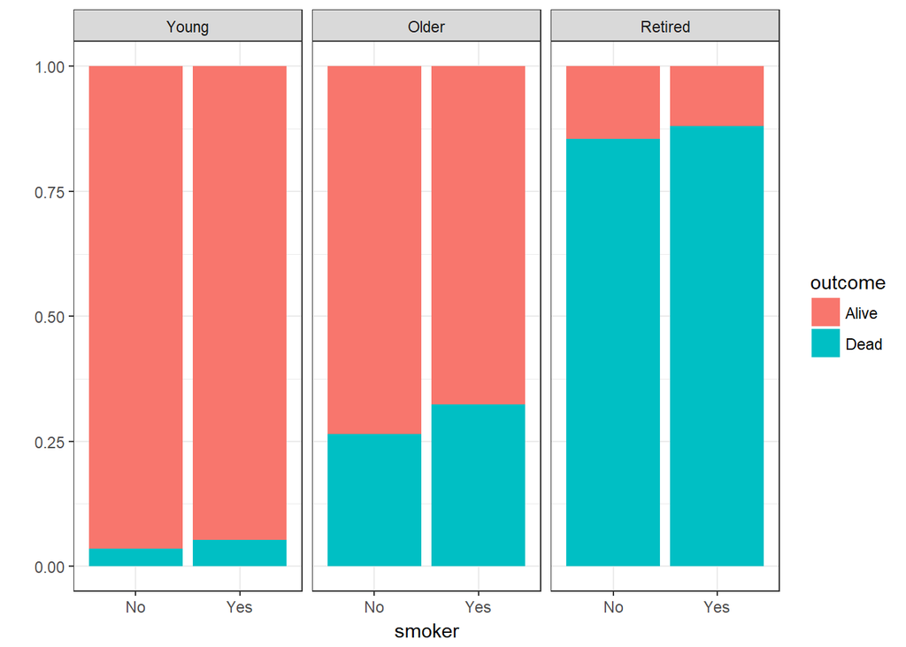

```r
Whickham <- Whickham %>% mutate(age_fct = factor(case_when(
  age <= 44 ~ 'Young',
  age > 44 & age <= 64 ~ 'Older',
  age > 64 ~ 'Retired'
), levels = c('Young', 'Older', 'Retired')))

Whickham %>% ggplot(aes(x = smoker, fill = outcome)) +
  geom_bar(position = 'fill') +
  labs(y = '') +
  facet_wrap(~age_fct) +
  theme_bw()
```

When broken down by age we see that the mortality rate for non-smokers appears to be lower than for smokers, across each age group. The reason the results were the opposite when all age groups were combined may be because of different sample sizes represented in each age group, along with different overall mortality rates.

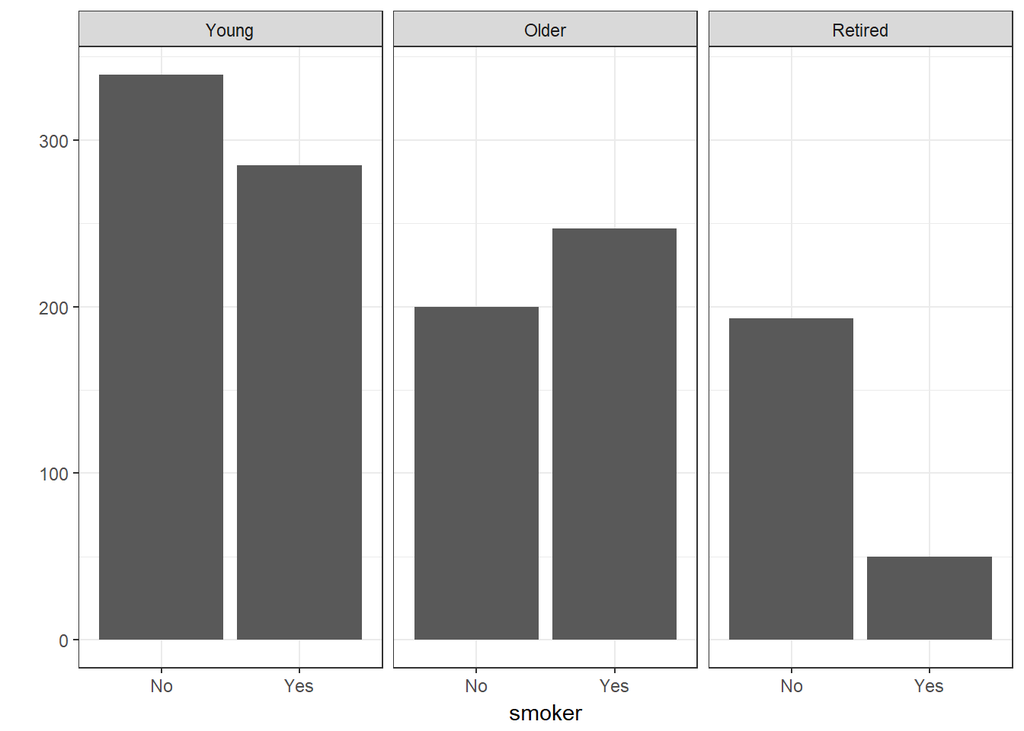

```r
Whickham %>% ggplot(aes(x = smoker)) +
  geom_bar() +
  labs(y = '') +
  facet_wrap(~age_fct) +
  theme_bw()
```

### Exercise 2

The Central Limit Theorem states that the sampling distribution of sample means is approximately Normal, regardless of the distribution of your population. For this exercise our population distribution will be a Gamma(1,2) distribution, and we’ll show that the sampling distribution of the mean is in fact normally distributed.

1. Generate a random sample of size n = 10000 from a gamma(1,2) distribution and plot a histogram or density curve. Use the code below to help you get your sample.

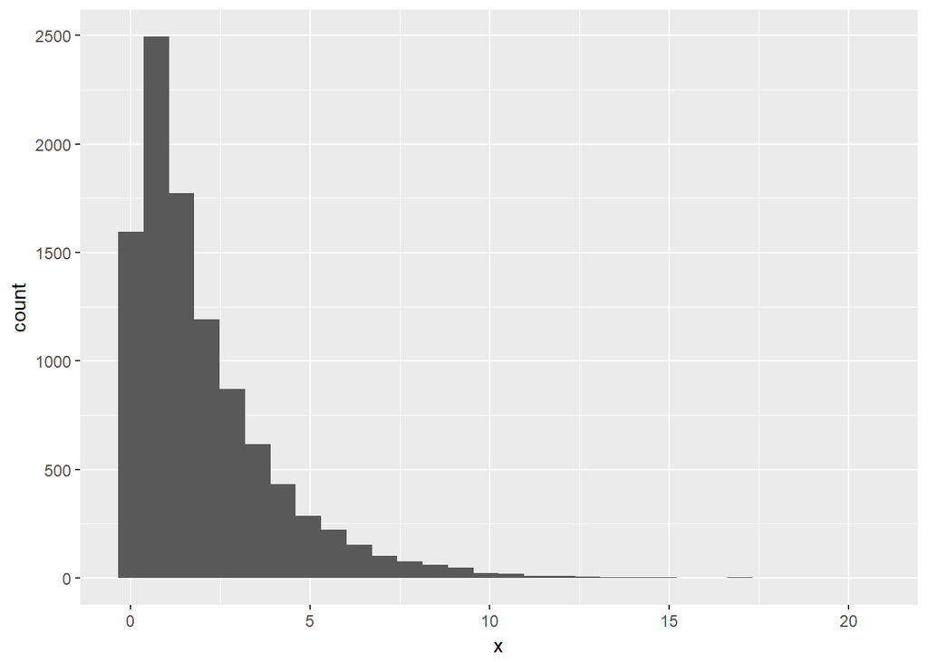

```r
library(tidyverse)
n <- 10000

# look at ?rgamma to read about this function
gamma_samp <- tibble(x = rgamma(n, shape = 1, scale = 2))

gamma_samp %>% ggplot(aes(x = x)) +
  geom_histogram()
```

2. What is the mean and standard deviation of your sample? They should both be close to 2 because for a gamma distribution:

mean = shape x scale  
variance = shape x scale^2

The mean is 2.0178604 and the standard deviation is 2.0162543.

```r
gamma_samp %>% .[['x']] %>% mean()
```

```
## [1] 2.01786
```

```r
gamma_samp %>% .[['x']] %>% sd()
```

```
## [1] 2.016254
```

3. Pretend the distribution of our **population** of data looks like the plot above. Now take a sample of size n = 30 from a Gamma(1,2) distribution, plot the histogram or density curve, and calculate the mean and standard deviation.

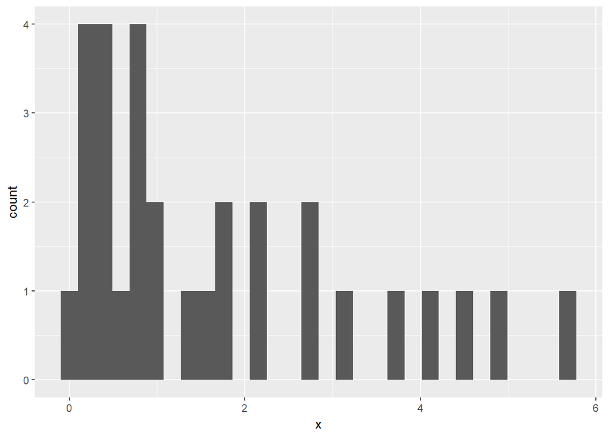

```r
n <- 30

# look at ?rgamma to read about this function
gamma_samp <- tibble(x = rgamma(n, shape = 1, scale = 2))

gamma_samp %>% ggplot(aes(x = x)) +
  geom_histogram()
```

```r
gamma_samp %>% .[['x']] %>% mean()
```

```
## [1] 1.695176
```

```r
gamma_samp %>% .[['x']] %>% sd()
```

```
## [1] 1.587526
```

4. Take a sample of size n = 30, again from the Gamma(1,2) distribution, calculate the mean, and assign it to a vector named `mean_samp`. Repeat this 10000 times!!!! The code below might help.

```r
# create a vector with 10000 NAs
mean_samp <- rep(NA, 10000)

# start a loop
for(i in 1:10000) {
  g_samp <- rgamma(30, shape = 1, scale = 2)
  mean_samp[i] <- mean(g_samp)
}
# Convert vector to a tibble
mean_samp <- tibble(mean_samp)
```

5. Make a histogram of your collection of means from above (`mean_samp`).

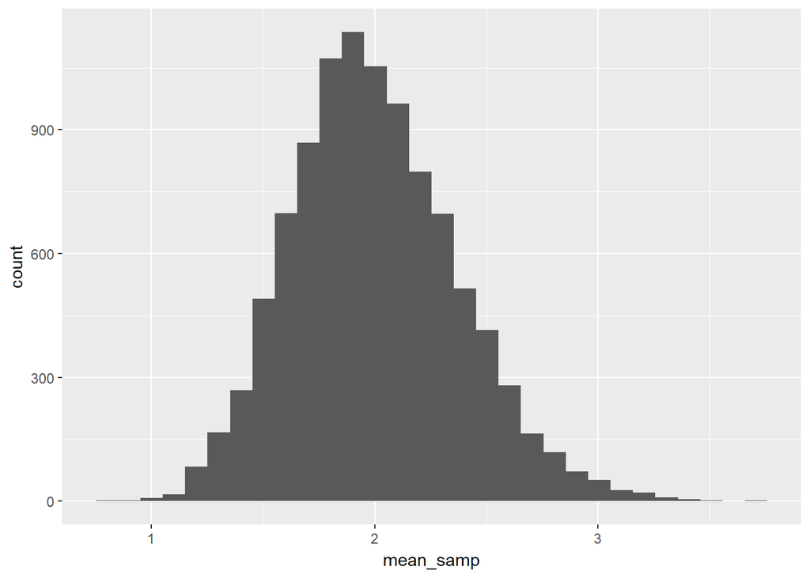

```r
mean_samp %>% ggplot(aes(x = mean_samp)) +
  geom_histogram()
```

6. Calculate the mean and standard deviation of all of your sample means.

```r
mean_samp %>% summarize(mean_samp_mean = mean(mean_samp), sd_samp_mean = sd(mean_samp))
```

| mean_samp_mean | sd_samp_mean |
| --- | --- |
| 2.000043 | 0.3693093 |

7. Did anything surprise you about your answers to #6?

Me? No. But others might be surprised to see that the standard deviation of your sample means is so small.

8. According to the Central Limit Theorem, the mean of your sampling distribution should be very close to 2, and the standard deviation of your sampling distribution should be close to $\large \frac{\sigma}{\sqrt{n}} = \frac{2}{\sqrt{30}} = 0.365$. Repeat #4-#6, but now with a sample of size n = 300 instead. Do your results match up well with the theorem?

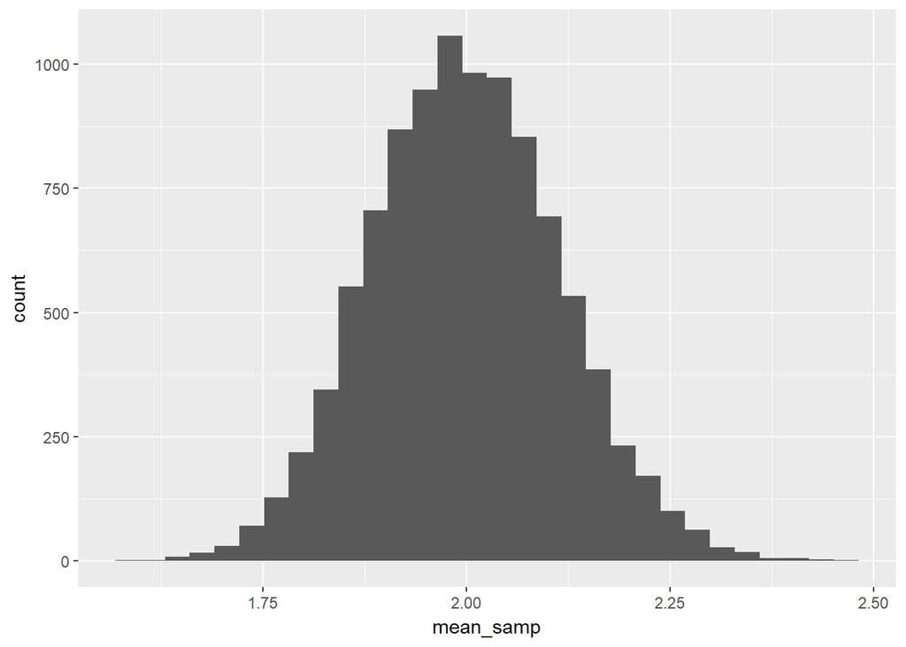

```r
# create a vector with 10000 NAs
mean_samp <- rep(NA, 10000)

# start a loop
for(i in 1:10000) {
  g_samp <- rgamma(300, shape = 1, scale = 2)
  mean_samp[i] <- mean(g_samp)
}
# Convert vector to a tibble
mean_samp <- tibble(mean_samp)

mean_samp %>% ggplot(aes(x = mean_samp)) +
  geom_histogram()
```

```r
mean_samp %>% summarize(mean_samp_mean = mean(mean_samp), sd_samp_mean = sd(mean_samp))
```

| mean_samp_mean | sd_samp_mean |
| --- | --- |
| 1.998793 | 0.1154724 |

Above we can see that the simulated standard error is 0.1154724. By the theorem, the standard error in this case should be 0.1154701. Our results agree well with the theorem.